# GibSia

Cal F-J, under supervision of Prof. David L Borchers

June 2017

## Examination of the dataset

```r
library('DEVDEV5') # load the development version of the LT2D package
Data = read.csv('GibbSia.csv',header=T) # load the x and y data
x = Data$PP.Distance ; y = Data$Forward.Distance # 73 observations
```

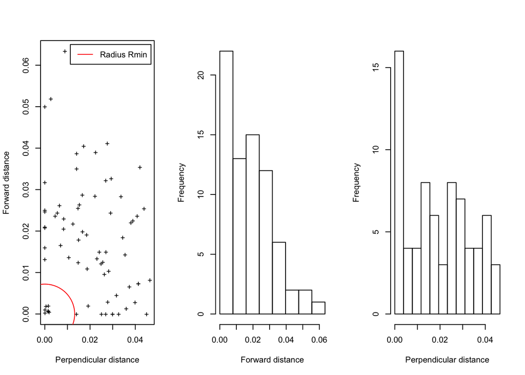

It would seem by inspection, that 0.05 seems a reasonable perpendicular truncation distance ($w=0.05$), and 0.06 seems reasonable for $ystart$; the furthest forward distance at which we are able to detect animals. We have a small cluster of values at distances close to (0,0), which is likely due to the rounding of recorded values in the field. Points at these coordinates have had a small amount of noise added to them in the scatter plot, to make the cluster more visible. We will check that the hazard model we fit is close to zero at this value. We notice a clear gap in the distribution of radial distances of detections between 0 and 0.0132, and so we take the latter of these values to be rmin.

Histogram of collected radial distances:

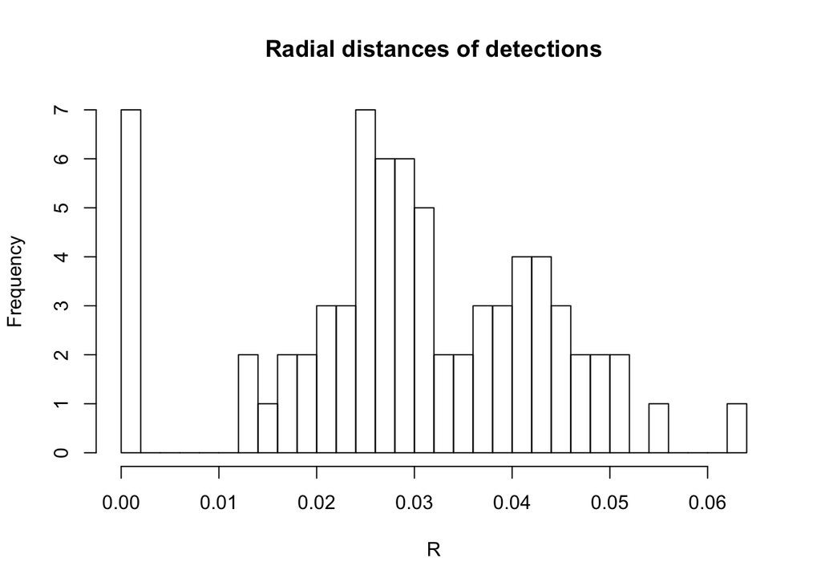

## Dealing with rounded distances.

The rounding down of small radial distances down to zero leads to loss of information; the true location of the detected animal could be at any radial distance within $0$ to $R_{min}$, where $R_{min}$ is the value below which all radial distances have been rounded to 0. We must reflect this uncertainty in true location in our likelihood:

$L_R(\boldsymbol{\beta};n)= L_U(\boldsymbol{\beta};m)\times\Bigg[ \frac{\int_0^{R_{min}} {\big\{{\large S}\left(y_{min}(x),\:x\:;\:\boldsymbol{\beta}\right) -{\large S}\left(0,\:x\:;\:\boldsymbol{\beta}\right)\big\} \pi(x\;;\:\boldsymbol{\phi})}\: dx} {\int_0^{R_{min}}\pi(x\:;\:\boldsymbol{\phi})\:dx} \times\frac{1}{\int_0^w p(x\:;\:\boldsymbol{\beta})\:\pi(x\;;\:\boldsymbol{\phi}) \:dx}\Bigg]^{n-m}$

Where $L_U(\boldsymbol{\beta};m)$ is the Borchers and Cox (2016) likelihood, evaluated at the m detections which have not been rounded down. $y_{min}(x)$ is the forward distance at which an animal travelling from $\infty$ to $0$ along the $y$ axis at perpendicular $x$ intersects the quarter circle of radius $R_{min}$ and centre located at the observer’s position. $S$ is the Borchers and Cox (2016) survivor function, and all remaining parameters also have the same definition as their presentation in Borchers and Cox (2016).

## Fitting some models:

```r
w=0.05;ystart=0.06 # set these to use in all our fits
```

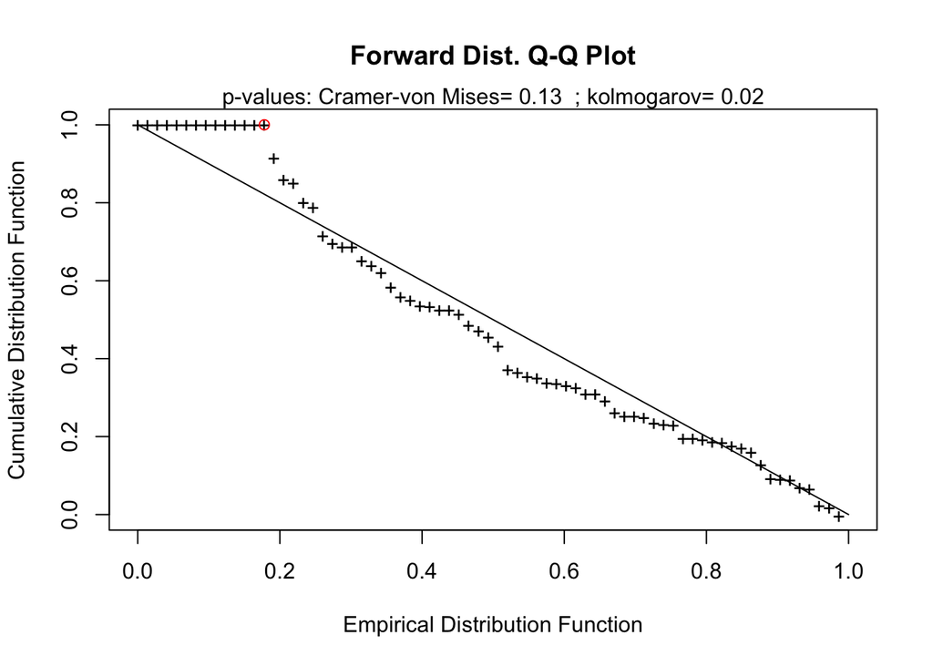

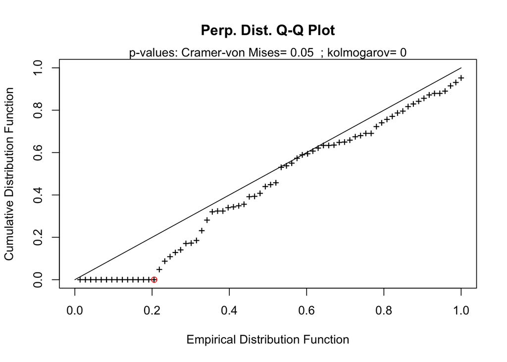

```r
# Normal bump with hazard h1: -- poor gof --
b=c(-6.82664896,1.09392846) ; logphi=c(-0.03503625,0.51044374)  # start values

fit.n=fityx(y,x,b=b,hr='h1',ystart=ystart,pi.x='pi.norm',logphi=logphi,0,rmin=rmin,
             w=w,hessian=TRUE,control=list(trace=0))            # fit

par(mfrow=c(1,1))
gof.LT2D(fit.n,plot=T)
```

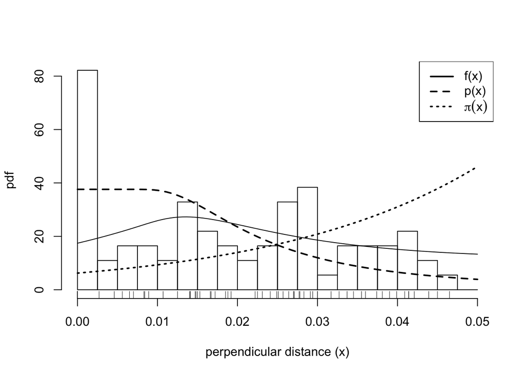

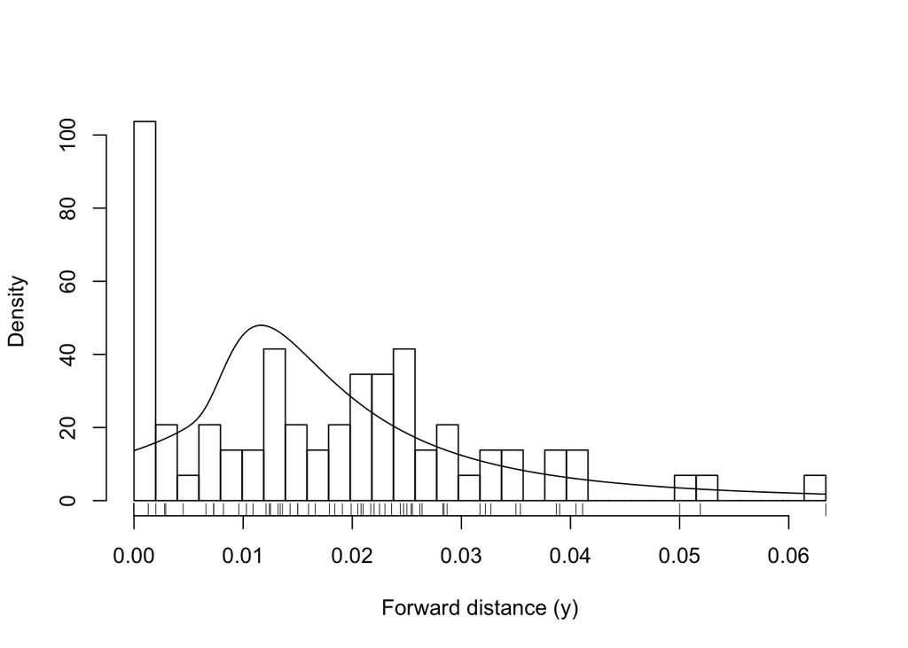

```r
plot(fit.n,xbins=20,ybins=32,smooth.fy=TRUE,addrug=TRUE)
```

```r
phatInterval(fit.n) ; phatInterval(fit.n)*w #EHSW

fit.n$p0 # p(0)
```

[output not shown]